# lab2

Lucia Nguyen

2026-09-07

# Tasks

## Task 1

Working directory.

```r
getwd()
```

```
## [1] "/Users/jeli/Desktop/Math 4753/lab2"
```

## Task 2

Read and obtain the first six lines of the data.

```r
epagas = read.csv("EPAGAS.csv")
head(epagas)
```

```
##    MPG
## 1 36.3
## 2 41.0
## 3 36.9
## 4 37.1
## 5 44.9
## 6 36.8
```

## Task 3

- Make the mpg object.Transform mpg to z.

```r
mpg = epagas$MPG
z = (mpg - mean(mpg)) / sd(mpg)
head(z)
```

```
## [1] -0.28702628  1.65681163 -0.03887676  0.04383975  3.26978352 -0.08023501
```

```r
print(paste0("Mean = ", round(mean(z), digits = 4)), quote = FALSE)
```

```
## [1] Mean = 0
```

```r
print(paste0("Variance = ", var(z)), quote = FALSE)
```

```
## [1] Variance = 1
```

```r
print(paste0("Standard Deviation = ", sd(z)), quote = FALSE)
```

```
## [1] Standard Deviation = 1
```

- Values of mpg that are possible outliers.

```r
mpg[abs(z) >= 2 & abs(z) <= 3]
```

```
## [1] 30.0 42.1 31.8
```

- Values of mpg that defined as outliers.

```r
mpg[abs(z) >3]
```

```
## [1] 44.9
```

- Construct a dotplot with colors.

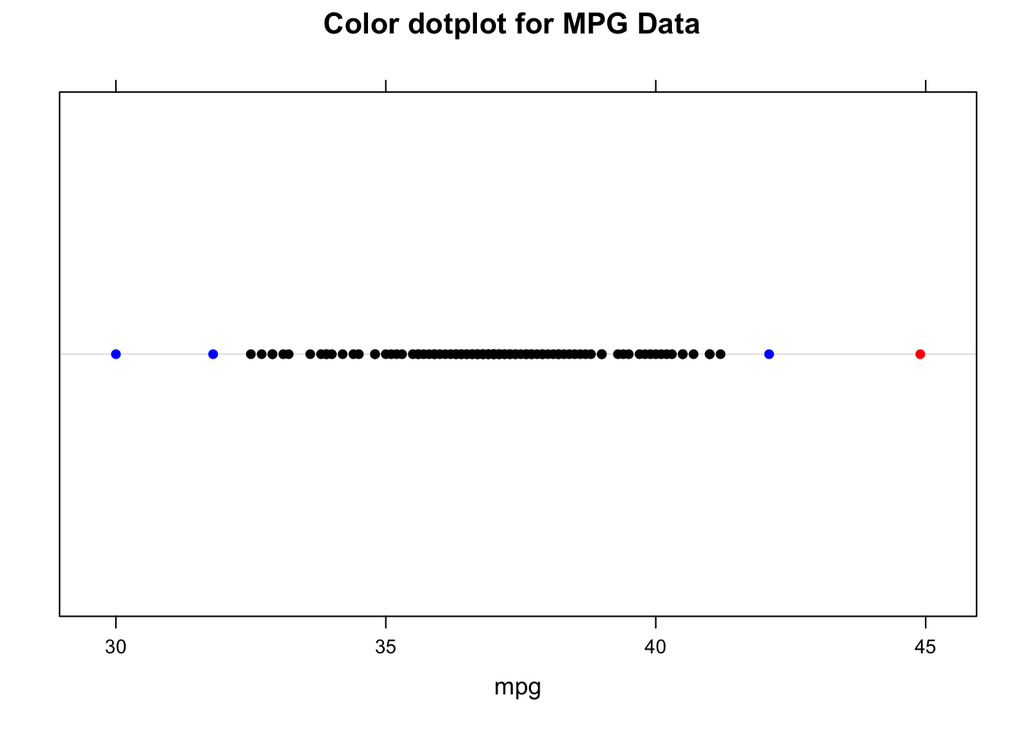

```r
mpgcol = ifelse(abs(z) > 3, "Red", ifelse(abs(z) >= 2 & abs(z) <= 3, "Blue", "Black"))
library(lattice)
dotplot(mpg, col = mpgcol, main = "Color dotplot for MPG Data")
```

## Task 4

- Boxplot of the mpg variable.

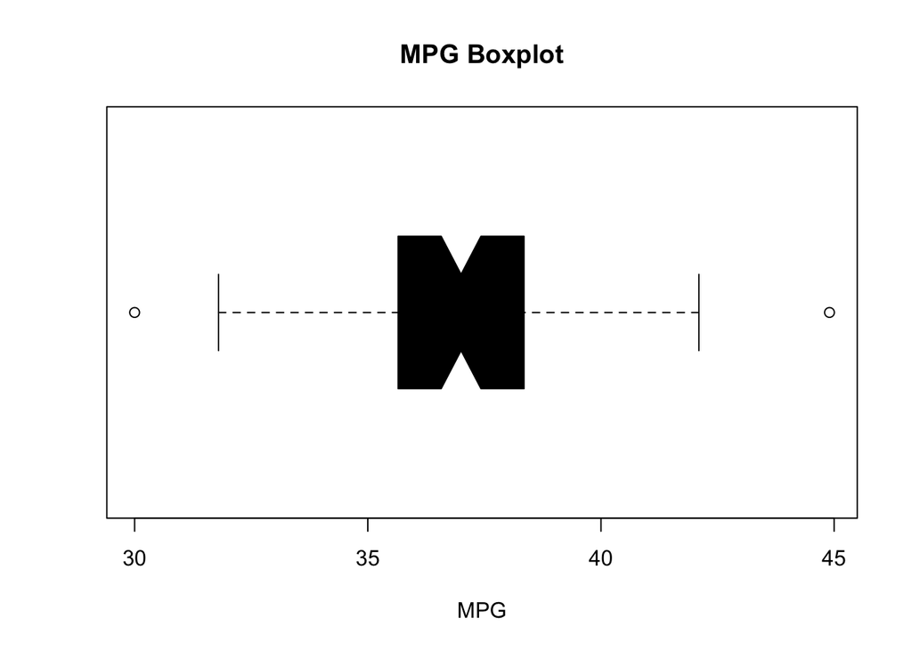

```r
boxplot(mpg, main = "MPG Boxplot", xlab = "MPG", col = "black", horizontal = TRUE, notch = TRUE)
```

- Predict with Chebyshev’s theorem.

The proportion of data within 2 standard deviations of the mean, using Chebyshev is at least $1 - \frac{1}{k^2}$ of data lies within k standard deviations. For k = 2,

```r
k = 2
1 - 1 / (k^2)
```

```
## [1] 0.75
```

- Calculate the exact proportion within 2 standard deviation of the mean.

```r
exactprop = length(mpg[abs(z) <= 2]) /length(mpg)
exactprop
```

```
## [1] 0.96
```

- Does Chebyshev agree with the data?

Yes. Chebyshev’s theorem guarantees that at least 75% of the data falls within 2 standard deviations of the mean, and the exact proportion value is 96% -> above that minimum. So the data satisfies the theorem’s bound.

- Empirical rule prediction:

The empirical rule states that for roughly bell-shaped data, about 95% of values fall within 2 standard deviations of the mean.

```r
   empirical_prop = 0.95
   empirical_prop
```

```
## [1] 0.95
```

- How well does it correspond?

Really well. The actual proportion (96%), which is extremely close to the empirical rule’s predicted of 95%.

- Is the empirical rule valid in this case? Why?

Yes, it’s valid here since the data is roughly bell-shaped/symmetric (in the boxplot and dotplot), and the actual proportion (96%) is very close to what the empirical rule predicted (95%).